# Median Incomes Analysis

Ammar Ali

9/29/2020

# Background

Based of people’s income level, you can predict the percentage of what they will donate to charity. This report solely looks at Emgage Contributors’ Zipcodes. The following table is IRS data from 2014 used for this analysis:

|  | Income.Level | Percentage.of.Income.Donated |
| --- | --- | --- |
| 1 | &lt; $25k | 12.3% |
| 2 | $25k - $50k | 6.8% |
| 3 | $50k - $75k | 4.8% |
| 4 | $75k - $100k | 3.8% |
| 5 | $100k - $200k | 3% |
| 6 | $200k - $500k | 2.6% |

## Step 1: The Distribution of Incomes

The following is a histogram showing the distribution of the median income levels for contributing Zipcodes:

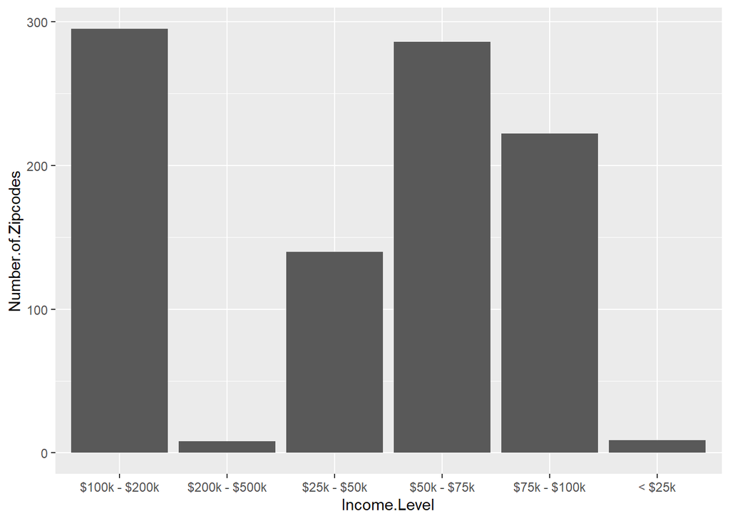

## Step 2: Estimated Donation Amounts for Each Zipcode per Income Bracket

The following tables give the estimated donation amount for each zipcode based on the percentage of AGI they give to charity. The total possible donations represents the maximum amount of contributions we could get from zipcodes in these respective income brackets if all the contacts donated their full estimated amount,

### Table 2: Zipcodes <$25K Income Bracket

|  | Zipcode | Number of Contacts | Median Household Income ($) | Estimated Donation Max ($) |
| --- | --- | --- | --- | --- |
| 1 | 78705 | 9 | 19188 | 2360 |
| 2 | 15213 | 2 | 22099 | 2718 |
| 3 | 75247 | 1 | 17798 | 2189 |
| 4 | 25301 | 1 | 22632 | 2784 |
| 5 | 90013 | 1 | 21676 | 2666 |
| 6 | 48201 | 1 | 15168 | 1866 |
| 7 | 48208 | 2 | 21070 | 2592 |
| 8 | 48238 | 1 | 24280 | 2986 |
| 9 | 48206 | 1 | 22308 | 2744 |

Total number of contacts: 19 | Total Possible Donations: $47,095

### Table 3: Zipcodes $25K - $50K Income Bracket

|  | Zipcode | Number of Contacts | Median Household Income ($) | Estimated Donation Max ($) |
| --- | --- | --- | --- | --- |
| 1 | 78753 | 6 | 49065 | 3336 |
| 2 | 38917 | 1 | 42665 | 2901 |
| 3 | 48221 | 2 | 41297 | 2808 |
| 4 | 48212 | 3 | 26435 | 1798 |
| 5 | 33617 | 21 | 37257 | 2533 |
| 6 | 32084 | 1 | 48691 | 3311 |
| 7 | 32204 | 2 | 40483 | 2753 |
| 8 | 33014 | 1 | 38846 | 2642 |
| 9 | 48198 | 3 | 45721 | 3109 |
| 10 | 78724 | 1 | 45887 | 3120 |

[output cut: 130 more lines]

Total number of contacts: 292 | Total Possible Donations: $811,413

### Table 4: Zipcodes $50K - $75 Income Bracket

|  | Zipcode | Number of Contacts | Median Household Income ($) | Estimated Donation Max ($) |
| --- | --- | --- | --- | --- |
| 1 | 33777 | 3 | 55650 | 2671 |
| 2 | 77055 | 3 | 53263 | 2557 |
| 3 | 34762 | 1 | 60781 | 2917 |
| 4 | 32825 | 3 | 57839 | 2776 |
| 5 | 34683 | 1 | 62766 | 3013 |
| 6 | 15236 | 2 | 66006 | 3168 |
| 7 | 20770 | 2 | 70561 | 3387 |
| 8 | 33176 | 4 | 70572 | 3387 |
| 9 | 33137 | 9 | 60259 | 2892 |
| 10 | 78702 | 6 | 59705 | 2866 |

[output cut: 276 more lines]

Total number of contacts: 613 | Total Possible Donations: $1,847,021

### Table 5: Zipcodes $75K - $100K Income Bracket

[output not shown]

[output cut: 212 more lines]

Total number of contacts: 740 | Total Possible Donations: $1,936,754

### Table 6: Zipcodes $100K - $200K Income Bracket

|  | Zipcode | Number of Contacts | Median Household Income ($) | Estimated Donation Max ($) |
| --- | --- | --- | --- | --- |
| 1 | 20009 | 7 | 107128 | 3214 |
| 2 | 77494 | 9 | 139669 | 4190 |
| 3 | 94542 | 1 | 108438 | 3253 |
| 4 | 94025 | 1 | 151279 | 4538 |
| 5 | 22101 | 18 | 195631 | 5869 |
| 6 | 11755 | 1 | 109490 | 3285 |
| 7 | 77459 | 5 | 107692 | 3231 |
| 8 | 20120 | 8 | 122165 | 3665 |
| 9 | 20724 | 4 | 103179 | 3095 |
| 10 | 78746 | 14 | 139951 | 4199 |

[output cut: 285 more lines]

Total number of contacts: 936 | Total Possible Donations: $3,608,743

### Table 7: Zipcodes $200K+ Income Bracket

[output not shown]

Total number of contacts: 28 | Total Possible Donations: $183,712

## Step 3: How much do Emgage Contacts Actuallly donate?

The following tables will contain the contacts average donation amount, and the percentage of their estimated donation amount that they donate to Emgage

### Table 8: Percentage Donated from <$25K Zipcodes

|  | VANID | First Name | Last Name | Zipcode | Home City | Home State | Number Of Contributions | Average Contribution Amount | Median Household Income ($) | Estimated Donation Max ($) | Percentage Donated (%) |
| --- | --- | --- | --- | --- | --- | --- | --- | --- | --- | --- | --- |
| 1 | 108157193 | Whitney | Bodman | 78705 | Austin | TX | 1 | 50 | 19188 | 2360 | 2 |
| 2 | 108492676 | Nicholas | Ybarra | 78705 | Austin | TX | 1 | 50 | 19188 | 2360 | 2 |
| 3 | 108945964 | Syed | Uddin | 15213 | Pittsburgh | PA | 1 | 250 | 22099 | 2718 | 9 |
| 4 | 109924848 | Farida | Khemani | 75247 | Dallas | TX | 1 | 100 | 17798 | 2189 | 5 |
| 5 | 108336422 | Guneez | Ibrahim | 78705 | Austin | TX | 1 | 50 | 19188 | 2360 | 2 |
| 6 | 105432532 | Ahmed | Sakkal | 25301 | Charleston | WV | 1 | 25 | 22632 | 2784 | 1 |
| 7 | 108858057 | Edwin | Lin | 90013 | Los Angeles | CA | 1 | 100 | 21676 | 2666 | 4 |
| 8 | 108490154 | Erin | Gaines | 78705 | Austin | TX | 1 | 50 | 19188 | 2360 | 2 |
| 9 | 108491666 | Yasmin | Eljirby | 78705 | Austin | TX | 1 | 50 | 19188 | 2360 | 2 |
| 10 | 108327756 | Santiago | Rosales | 78705 | Austin | TX | 1 | 50 | 19188 | 2360 | 2 |

[output cut: 9 more lines]

Average Percentage Donated: 7.32% | Average Average Contribution Amount: $186.72

### Table 9: Percentage Donated from $25K - $50K Zipcodes

|  | VANID | First Name | Last Name | Zipcode | Home City | Home State | Number Of Contributions | Average Contribution Amount | Median Household Income ($) | Estimated Donation Max ($) | Percentage Donated (%) |
| --- | --- | --- | --- | --- | --- | --- | --- | --- | --- | --- | --- |
| 1 | 108226548 | Clay Chip | Smith | 78753 | Austin | TX | 3 | 213.3333 | 49065 | 3336 | 6 |
| 2 | 109922028 | Robert W Neill Jr | Neill Jr | 38917 | Carrollton | MS | 1 | 5 | 42665 | 2901 | 0 |
| 3 | 106468379 | Jeffrey | Nolish | 48221 | Detroit | MI | 2 | 15 | 41297 | 2808 | 1 |
| 4 | 106544491 | Abraham | Aiyash | 48212 | Hamtramck | MI | 1 | 35 | 26435 | 1798 | 2 |
| 5 | 108288400 | Naba | Naser | 33617 | Tampa | FL | 1 | 85 | 37257 | 2533 | 3 |
| 6 | 108288536 | Najib | Albadrasawi | 33617 | Tampa | FL | 1 | 25 | 37257 | 2533 | 1 |
| 7 | 109921039 | Ahmed | Bata | 32084 | Saint Augustine | FL | 1 | 250 | 48691 | 3311 | 8 |
| 8 | 108327713 | Sarah | Usman | 32204 | Jacksonville | FL | 1 | 110 | 40483 | 2753 | 4 |
| 9 | 104267897 | Akhtar | Mahmood | 33014 | Miami Lakes | FL | 1 | 50 | 38846 | 2642 | 2 |
| 10 | 108136874 | Muhammad | Jilani | 48198 | Ypsilanti | MI | 1 | 1000 | 45721 | 3109 | 32 |

[output cut: 282 more lines]

Average Percentage Donated: 27.91% | Average Average Contribution: $722.80

### Table 10: Percentage Donated from $50K - $75K Zipcodes

|  | VANID | First Name | Last Name | Zipcode | Home City | Home State | Number Of Contributions | Average Contribution Amount | Median Household Income ($) | Estimated Donation Max ($) | Percentage Donated (%) |
| --- | --- | --- | --- | --- | --- | --- | --- | --- | --- | --- | --- |
| 1 | 109401468 | Syed Masood | Gilani | 33777 | Seminole | FL | 1 | 100 | 55650 | 2671 | 4 |
| 2 | 104261916 | Tara | Turk-Zaafran | 77055 | Houston | TX | 1 | 100 | 53263 | 2557 | 4 |
| 3 | 104268668 | Susan | Salazar | 34762 | Okahumpka | FL | 1 | 25 | 60781 | 2917 | 1 |
| 4 | 104268703 | Nada | Sleem | 32825 | Orlando | FL | 2 | 50 | 57839 | 2776 | 2 |
| 5 | 107302133 | Stephen | Giunta | 34683 | Palm Harbor | FL | 1 | 25 | 62766 | 3013 | 1 |
| 6 | 108609514 |  |  | 15236 | Pittsburgh | PA | 1 | 500 | 66006 | 3168 | 16 |
| 7 | 109920833 | Mohammed | Sarwar | 20770 | Greenbelt | MD | 1 | 20 | 70561 | 3387 | 1 |
| 8 | 104268930 | Imtiaz | Mohammad | 33176 | Miami | FL | 1 | 30 | 70572 | 3387 | 1 |
| 9 | 104268930 | Imtiaz | Mohammad | 33176 | Miami | FL | 2 | 50 | 70572 | 3387 | 1 |
| 10 | 108286804 | Angela | Locarno | 33137 | Miami | FL | 1 | 240 | 60259 | 2892 | 8 |

[output cut: 603 more lines]

Average Percentage Donated: 16.77% | Average Average Contribution: $504.70

### Table 11: Percentage Donated from $75K - $100K Zipcodes

|  | VANID | First Name | Last Name | Zipcode | Home City | Home State | Number Of Contributions | Average Contribution Amount | Median Household Income ($) | Estimated Donation Max ($) | Percentage Donated (%) |
| --- | --- | --- | --- | --- | --- | --- | --- | --- | --- | --- | --- |
| 1 | 104261448 | Khurrum | Wahid | 33071 | Coral Springs | FL | 15 | 758.1826 | 89440 | 2683 | 28 |
| 2 | 104261448 | Khurrum | Wahid | 33071 | Coral Springs | FL | 1 | 30 | 89440 | 2683 | 1 |
| 3 | 109921227 | Mohammed | Sayeed | 60148 | Lombard | IL | 1 | 1 | 81504 | 2445 | 0 |
| 4 | 104268718 | Jafer | Ahmad | 20005 | Washington | DC | 5 | 210 | 94611 | 2838 | 7 |
| 5 | 108485327 | Syed | Zaheer | 78660 | Pflugerville | TX | 1 | 200 | 83499 | 2505 | 8 |
| 6 | 108136911 | Kamal | Mubarak | 48103 | Ann Arbor | MI | 1 | 100 | 91962 | 2759 | 4 |
| 7 | 104268679 | Nadia | Daud | 98407 | Tacoma | WA | 1 | 25 | 76342 | 2290 | 1 |
| 8 | 104268679 | Nadia | Daud | 98407 | Tacoma | WA | 2 | 50 | 76342 | 2290 | 2 |
| 9 | 108598877 |  |  | 20036 | Washington | DC | 1 | 21000 | 88553 | 2657 | 790 |
| 10 | 109922656 | Quiana | Johnson | 32258 | Jacksonville | FL | 1 | 1 | 80207 | 2406 | 0 |

[output cut: 730 more lines]

Average Percentage Donated: 41.37% Average Average Contribution: $1154.66

### Table 12: Percentage Donated from $100K - $200K Zipcodes

|  | VANID | First Name | Last Name | Zipcode | Home City | Home State | Number Of Contributions | Average Contribution Amount | Median Household Income ($) | Estimated Donation Max ($) | Percentage Donated (%) |
| --- | --- | --- | --- | --- | --- | --- | --- | --- | --- | --- | --- |
| 1 | 104260997 | Amber | Jamil | 20009 | Washington | DC | 1 | 65 | 107128 | 3214 | 2 |
| 2 | 109921278 | Raheem | Asif | 77494 | Katy | TX | 1 | 1 | 139669 | 4190 | 0 |
| 3 | 104268654 | Ryan | Panos | 94542 | Hayward | CA | 1 | 30 | 108438 | 3253 | 1 |
| 4 | 104268685 | Karen | Grove | 94025 | Menlo Park | CA | 2 | 1251 | 151279 | 4538 | 28 |
| 5 | 108840413 |  |  | 22101 | McLean | VA | 2 | 25000 | 195631 | 5869 | 426 |
| 6 | 109922964 | Talat | Hamdani | 11755 | Lake Grove | NY | 1 | 5 | 109490 | 3285 | 0 |
| 7 | 109922981 | Redouane | Rostane | 77459 | Missouri City | TX | 1 | 20 | 107692 | 3231 | 1 |
| 8 | 106606526 | Seema | Khan | 20120 | Centreville | VA | 2 | 809.85 | 122165 | 3665 | 22 |
| 9 | 106606526 | Seema | Khan | 20120 | Centreville | VA | 4 | 400 | 122165 | 3665 | 11 |
| 10 | 106669498 | Shansha | Ali | 20724 | Laurel | MD | 2 | 500 | 103179 | 3095 | 16 |

[output cut: 926 more lines]

Average Percentage Donated: 20.76% Average Average Contribution Amount: $793.49

### Table 13: Percentage Donated from $200K+ Zipcodes

[output not shown]

[output cut: 954 more lines]

Average Percentage Donated: 20.32% Average Average Contribution: $781.67